# Making maps in R:

Using the sf and tmap Packages

Carlos Mendez

Suggested Citation:

> Mendez C. (2020). Making maps in R: Using the sf and tmap Packages. R Studio/RPubs. Available at https://rpubs.com/quarcs-lab/tutorial-maps-in-r

This work is licensed under the Creative Commons Attribution-Share Alike 4.0 International License.

[figure not shown]

# 1 Libraries

```r
knitr::opts_chunk$set(echo = TRUE, warning=FALSE)

library(tidyverse)  # Modern data science workflow
library(sf)         # Simple features for R
library(tmap)       # Thematic Maps
library(tmaptools)  # Thematic Maps Tools
library(RColorBrewer) # ColorBrewer Palettes
library(leaflet)    # Interactive web maps
library(rgdal)      # Bindings for the Geospatial Data Abstraction Library
library(rgeos)      # Interface to Geometry Engine - Open Source


# Change the presentation of decimal numbers to 4 and avoid scientific notation
options(prompt="R> ", digits=4, scipen=999)
```

# 2 Tutorial objectives

- Load spatial data files into R
- Join non-spaital data to spatial data files
- Create simple choropleth maps

# 3 Orginal data sources

The non-spatial datafile is from:

- Öcal, N., & Yildirim, J. (2010). [Regional effects of terrorism on economic growth in Turkey: A geographically weighted regression approach.](https://journals.sagepub.com/doi/abs/10.1177/0022343310364576) Journal of Peace Research, 47(4), 477-489.

The spatial (shapefile) is from:

- [Matthew C. Ingram](http://mattingram.net/)

# 4 Import the data

## 4.1 Non-spatial data

```r
dat <-read.csv("DATASET.csv")
```

### 4.1.1 Explore the data

```r
glimpse(dat)
```

```
Observations: 67
Variables: 7
$ id      <int> 1, 2, 3, 4, 5, 7, 8, 9, 10, 11, 12, 13, 15, 16, 17, 18, 19, 20, 22, 23, 24, 25, 26, 28, 30, 31, 33, 32, 34, 35, 46…
$ growth  <dbl> 0.0254, -0.0254, 0.0773, 0.2583, 0.0709, 0.0247, 0.1059, 0.0395, 0.0186, 0.1536, 0.1687, -0.0012, 0.0977, 0.0412, …
$ base    <dbl> 6.157, 5.900, 5.896, 5.315, 5.923, 6.198, 6.075, 6.173, 6.150, 6.284, 5.511, 5.566, 6.069, 6.291, 6.188, 5.887, 5.…
$ T       <dbl> 3.585, 2.896, 2.763, 3.140, 2.785, 4.118, 3.296, 3.163, 2.740, 2.718, 3.451, 3.407, 2.718, 2.807, 2.718, 3.474, 2.…
$ E       <dbl> 5.216, 3.458, 4.995, 3.478, 4.805, 5.492, 4.852, 5.131, 5.146, 5.245, 3.457, 3.583, 5.379, 5.599, 5.083, 4.717, 4.…
$ G       <dbl> 6.192, 6.048, 5.950, 5.354, 5.940, 6.200, 6.113, 6.219, 6.155, 6.340, 5.565, 5.619, 6.088, 6.313, 6.194, 5.932, 6.…
$ Coastal <int> 0, 0, 0, 0, 0, 1, 1, 1, 1, 0, 0, 0, 0, 1, 1, 0, 0, 0, 0, 0, 0, 0, 0, 1, 0, 1, 1, 0, 1, 0, 0, 0, 0, 0, 0, 1, 0, 0, …
```

#### 4.1.1.1 Definitions of variables

- growth: growth rate of per capita real income 1987-2001
- base: lograrithm of the per apita income in the base year 1987
- T: average terrorism index
- E: average years of schooling
- G: real per capita government expenditures in 1987
- Coastal: dummy variable which takes the value of one if the province is a coastal province.

## 4.2 Spatial data

```r
mapData <- read_sf("MAP.shp")
```

### 4.2.1 Explore the data

```r
glimpse(mapData)
```

```
Observations: 67
Variables: 21
$ ObjectID   <int> 1946, 1949, 1952, 1957, 2116, 2150, 2186, 2236, 2278, 2371, 2375, 2393, 2458, 2463, 2501, 2507, 2600, 2657, 273…
$ NAME       <chr> "Adana", "Adiyaman", "Afyon", "Agri", "Amasya", "Antalya", "Artvin", "Aydin", "Balikesir", "Bilecik", "Bingöl",…
$ COUNTRY    <chr> "Turkey", "Turkey", "Turkey", "Turkey", "Turkey", "Turkey", "Turkey", "Turkey", "Turkey", "Turkey", "Turkey", "…
$ ISO_CODE   <chr> "TR01", "TR02", "TR03", "TR04", "TR05", "TR07", "TR08", "TR09", "TR10", "TR11", "TR12", "TR13", "TR15", "TR16",…
$ ISO_CC     <chr> "TR", "TR", "TR", "TR", "TR", "TR", "TR", "TR", "TR", "TR", "TR", "TR", "TR", "TR", "TR", "TR", "TR", "TR", "TR…
$ ISO_SUB    <chr> "01", "02", "03", "04", "05", "07", "08", "09", "10", "11", "12", "13", "15", "16", "17", "18", "19", "20", "22…
$ ADMINTYPE  <chr> "Province", "Province", "Province", "Province", "Province", "Province", "Province", "Province", "Province", "Pr…
$ DISPUTED   <int> 0, 0, 0, 0, 0, 0, 0, 0, 0, 0, 0, 0, 0, 0, 0, 0, 0, 0, 0, 0, 0, 0, 0, 0, 0, 0, 0, 0, 0, 0, 0, 0, 0, 0, 0, 0, 0, …
$ NOTES      <chr> NA, NA, NA, NA, NA, NA, NA, NA, NA, NA, NA, NA, NA, NA, NA, NA, NA, NA, NA, NA, NA, NA, NA, NA, NA, NA, NA, NA,…
$ AUTONOMOUS <int> 0, 0, 0, 0, 0, 0, 0, 0, 0, 0, 0, 0, 0, 0, 0, 0, 0, 0, 0, 0, 0, 0, 0, 0, 0, 0, 0, 0, 0, 0, 0, 0, 0, 0, 0, 0, 0, …
$ COUNTRYAFF <chr> "Turkey", "Turkey", "Turkey", "Turkey", "Turkey", "Turkey", "Turkey", "Turkey", "Turkey", "Turkey", "Turkey", "…
$ CONTINENT  <chr> "Asia", "Asia", "Asia", "Asia", "Asia", "Asia", "Asia", "Asia", "Asia", "Asia", "Asia", "Asia", "Asia", "Asia",…
$ Land_Type  <chr> "Primary land", "Primary land", "Primary land", "Primary land", "Primary land", "Primary land", "Primary land",…
$ Land_Rank  <int> 5, 5, 5, 5, 5, 5, 5, 5, 5, 5, 5, 5, 5, 5, 5, 5, 5, 5, 5, 5, 5, 5, 5, 5, 5, 5, 5, 5, 5, 5, 5, 5, 5, 5, 5, 5, 5, …
$ Shape_Leng <dbl> 8.589, 5.355, 6.698, 6.553, 4.831, 10.889, 4.740, 6.039, 9.599, 3.188, 5.689, 4.965, 4.669, 6.313, 5.031, 5.433…
$ Shape_Area <dbl> 1.6029, 0.8622, 1.4795, 1.1537, 0.6232, 2.1533, 0.7467, 0.7996, 1.4894, 0.5155, 0.8781, 0.9647, 0.7110, 1.1598,…
$ idnum      <int> 1, 2, 3, 4, 5, 7, 8, 9, 10, 11, 12, 13, 15, 16, 17, 18, 19, 20, 22, 23, 24, 25, 26, 28, 30, 31, 33, 32, 34, 35,…
$ province   <chr> "Adana", "Adiyaman", "Afyon", "Agri", "Amasya", "Antalya", "Artvin", "Aydin", "Balikesir", "Bilecik", "Bingol",…
$ id         <dbl> 1, 2, 3, 4, 5, 7, 8, 9, 10, 11, 12, 13, 15, 16, 17, 18, 19, 20, 22, 23, 24, 25, 26, 28, 30, 31, 33, 32, 34, 35,…
$ name_esri  <chr> NA, NA, NA, NA, NA, NA, NA, NA, NA, NA, NA, NA, NA, NA, NA, NA, NA, NA, "Batman", NA, NA, NA, NA, NA, NA, NA, N…
$ geometry   <POLYGON [°]> POLYGON ((36.44 38.22, 36.4..., POLYGON ((39.15 38.18, 39.1..., POLYGON ((31.7 39.16, 31.69..., POLYGON…
```

- Check the Coordinate Reference System

```r
st_crs(mapData)
```

```
Coordinate Reference System:
  EPSG: 4326
  proj4string: "+proj=longlat +datum=WGS84 +no_defs"
```

# 5 Transform the data

No need to transform any data because both datasets share a common variable `id`

# 6 Merge the data

```r
dat_map <- inner_join(
  dat,
  mapData,
  by = "id"
)
```

## 6.1 Keep data as sf object

- Keep the data as sf class, so we will not lose the coodinate system

```r
dat_map <- st_as_sf(dat_map)
st_crs(mapData)
```

```
Coordinate Reference System:
  EPSG: 4326
  proj4string: "+proj=longlat +datum=WGS84 +no_defs"
```

```r
glimpse(dat_map)
```

```
Observations: 67
Variables: 27
$ id         <dbl> 1, 2, 3, 4, 5, 7, 8, 9, 10, 11, 12, 13, 15, 16, 17, 18, 19, 20, 22, 23, 24, 25, 26, 28, 30, 31, 33, 32, 34, 35,…
$ growth     <dbl> 0.0254, -0.0254, 0.0773, 0.2583, 0.0709, 0.0247, 0.1059, 0.0395, 0.0186, 0.1536, 0.1687, -0.0012, 0.0977, 0.041…
$ base       <dbl> 6.157, 5.900, 5.896, 5.315, 5.923, 6.198, 6.075, 6.173, 6.150, 6.284, 5.511, 5.566, 6.069, 6.291, 6.188, 5.887,…
$ T          <dbl> 3.585, 2.896, 2.763, 3.140, 2.785, 4.118, 3.296, 3.163, 2.740, 2.718, 3.451, 3.407, 2.718, 2.807, 2.718, 3.474,…
$ E          <dbl> 5.216, 3.458, 4.995, 3.478, 4.805, 5.492, 4.852, 5.131, 5.146, 5.245, 3.457, 3.583, 5.379, 5.599, 5.083, 4.717,…
$ G          <dbl> 6.192, 6.048, 5.950, 5.354, 5.940, 6.200, 6.113, 6.219, 6.155, 6.340, 5.565, 5.619, 6.088, 6.313, 6.194, 5.932,…
$ Coastal    <int> 0, 0, 0, 0, 0, 1, 1, 1, 1, 0, 0, 0, 0, 1, 1, 0, 0, 0, 0, 0, 0, 0, 0, 1, 0, 1, 1, 0, 1, 0, 0, 0, 0, 0, 0, 1, 0, …
$ ObjectID   <int> 1946, 1949, 1952, 1957, 2116, 2150, 2186, 2236, 2278, 2371, 2375, 2393, 2458, 2463, 2501, 2507, 2600, 2657, 273…
$ NAME       <chr> "Adana", "Adiyaman", "Afyon", "Agri", "Amasya", "Antalya", "Artvin", "Aydin", "Balikesir", "Bilecik", "Bingöl",…
$ COUNTRY    <chr> "Turkey", "Turkey", "Turkey", "Turkey", "Turkey", "Turkey", "Turkey", "Turkey", "Turkey", "Turkey", "Turkey", "…
$ ISO_CODE   <chr> "TR01", "TR02", "TR03", "TR04", "TR05", "TR07", "TR08", "TR09", "TR10", "TR11", "TR12", "TR13", "TR15", "TR16",…
$ ISO_CC     <chr> "TR", "TR", "TR", "TR", "TR", "TR", "TR", "TR", "TR", "TR", "TR", "TR", "TR", "TR", "TR", "TR", "TR", "TR", "TR…
$ ISO_SUB    <chr> "01", "02", "03", "04", "05", "07", "08", "09", "10", "11", "12", "13", "15", "16", "17", "18", "19", "20", "22…
$ ADMINTYPE  <chr> "Province", "Province", "Province", "Province", "Province", "Province", "Province", "Province", "Province", "Pr…
$ DISPUTED   <int> 0, 0, 0, 0, 0, 0, 0, 0, 0, 0, 0, 0, 0, 0, 0, 0, 0, 0, 0, 0, 0, 0, 0, 0, 0, 0, 0, 0, 0, 0, 0, 0, 0, 0, 0, 0, 0, …
$ NOTES      <chr> NA, NA, NA, NA, NA, NA, NA, NA, NA, NA, NA, NA, NA, NA, NA, NA, NA, NA, NA, NA, NA, NA, NA, NA, NA, NA, NA, NA,…
$ AUTONOMOUS <int> 0, 0, 0, 0, 0, 0, 0, 0, 0, 0, 0, 0, 0, 0, 0, 0, 0, 0, 0, 0, 0, 0, 0, 0, 0, 0, 0, 0, 0, 0, 0, 0, 0, 0, 0, 0, 0, …
$ COUNTRYAFF <chr> "Turkey", "Turkey", "Turkey", "Turkey", "Turkey", "Turkey", "Turkey", "Turkey", "Turkey", "Turkey", "Turkey", "…
$ CONTINENT  <chr> "Asia", "Asia", "Asia", "Asia", "Asia", "Asia", "Asia", "Asia", "Asia", "Asia", "Asia", "Asia", "Asia", "Asia",…
$ Land_Type  <chr> "Primary land", "Primary land", "Primary land", "Primary land", "Primary land", "Primary land", "Primary land",…
$ Land_Rank  <int> 5, 5, 5, 5, 5, 5, 5, 5, 5, 5, 5, 5, 5, 5, 5, 5, 5, 5, 5, 5, 5, 5, 5, 5, 5, 5, 5, 5, 5, 5, 5, 5, 5, 5, 5, 5, 5, …
$ Shape_Leng <dbl> 8.589, 5.355, 6.698, 6.553, 4.831, 10.889, 4.740, 6.039, 9.599, 3.188, 5.689, 4.965, 4.669, 6.313, 5.031, 5.433…
$ Shape_Area <dbl> 1.6029, 0.8622, 1.4795, 1.1537, 0.6232, 2.1533, 0.7467, 0.7996, 1.4894, 0.5155, 0.8781, 0.9647, 0.7110, 1.1598,…
$ idnum      <int> 1, 2, 3, 4, 5, 7, 8, 9, 10, 11, 12, 13, 15, 16, 17, 18, 19, 20, 22, 23, 24, 25, 26, 28, 30, 31, 33, 32, 34, 35,…
$ province   <chr> "Adana", "Adiyaman", "Afyon", "Agri", "Amasya", "Antalya", "Artvin", "Aydin", "Balikesir", "Bilecik", "Bingol",…
$ name_esri  <chr> NA, NA, NA, NA, NA, NA, NA, NA, NA, NA, NA, NA, NA, NA, NA, NA, NA, NA, "Batman", NA, NA, NA, NA, NA, NA, NA, N…
$ geometry   <POLYGON [°]> POLYGON ((36.44 38.22, 36.4..., POLYGON ((39.15 38.18, 39.1..., POLYGON ((31.7 39.16, 31.69..., POLYGON…
```

# 7 Plot Thematic Maps

## 7.1 Quick Map

- A quick map of the Terrorism variable

```
The shape dat_map is invalid. See sf::st_is_valid
```

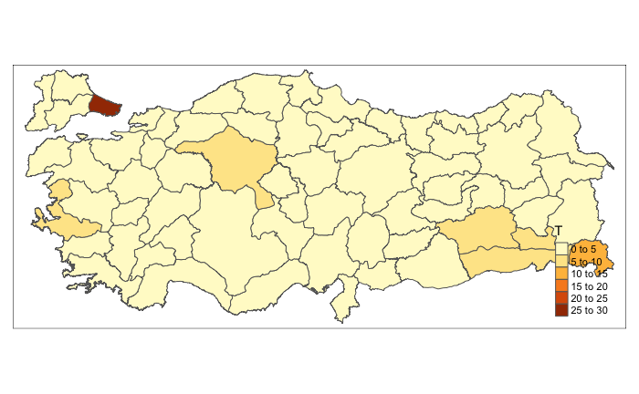

```r
qtm(dat_map, fill = "T")
```

## 7.2 Simple Map

```
The shape dat_map is invalid. See sf::st_is_valid
```

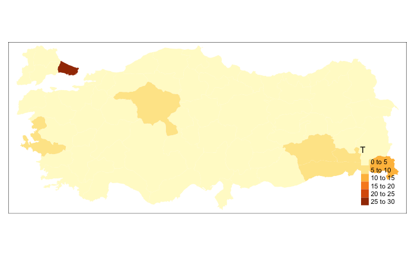

```r
tm_shape(dat_map) + tm_fill("T")
```

## 7.3 Remove frame

```
The shape dat_map is invalid. See sf::st_is_valid
```

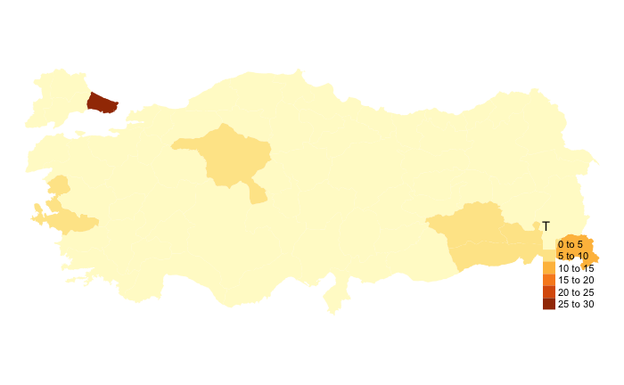

```r
tm_shape(dat_map) +
  tm_fill("T") +
  tm_layout(frame = FALSE)
```

## 7.4 Set legend outside

```
The shape dat_map is invalid. See sf::st_is_valid
```

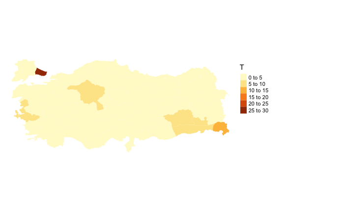

```r
tm_shape(dat_map) + tm_fill("T") +
  tm_layout(legend.outside = TRUE, frame = FALSE)
```

## 7.5 Set color palette

See color reference [here](https://www.datanovia.com/en/blog/the-a-z-of-rcolorbrewer-palette/)

```
The shape dat_map is invalid. See sf::st_is_valid
```

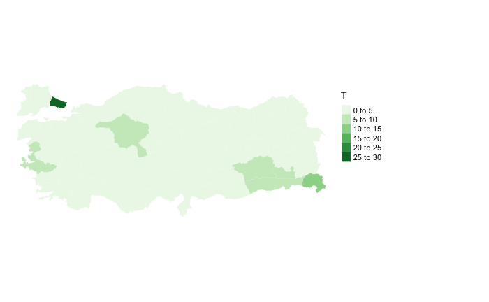

```r
tm_shape(dat_map) +
  tm_fill("T", palette = "Greens") +
  tm_layout(
    legend.outside = TRUE,
    frame = FALSE)
```

```
The shape dat_map is invalid. See sf::st_is_valid
```

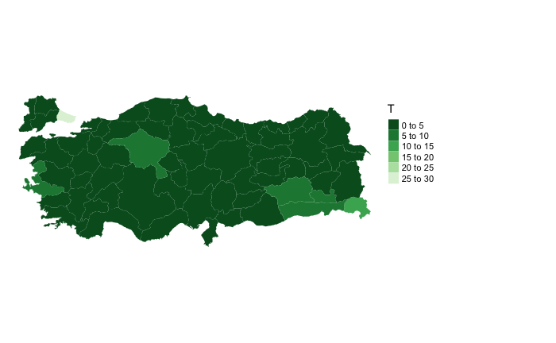

```r
tm_shape(dat_map) +
  tm_fill("T", palette = "-Greens") +
  tm_layout(
    legend.outside = TRUE,
    frame = FALSE)
```

```
The shape dat_map is invalid. See sf::st_is_valid
```

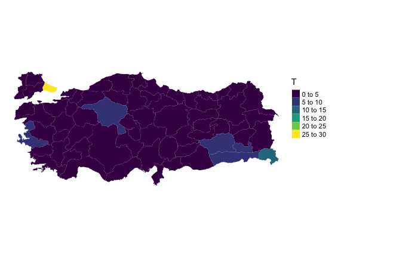

```r
tm_shape(dat_map) +
  tm_fill("T", palette = "viridis") +
  tm_layout(legend.outside = TRUE, frame = FALSE)
```

## 7.6 Add polygon names

```
The shape dat_map is invalid. See sf::st_is_valid
```

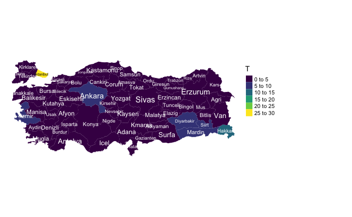

```r
tm_shape(dat_map) +
  tm_fill("T", palette = "viridis") +
  tm_layout(legend.outside = TRUE, frame = FALSE) +
  tm_text("province", size = "Shape_Area",  auto.placement = F, legend.size.show = FALSE)
```

```
The shape dat_map is invalid. See sf::st_is_valid
```

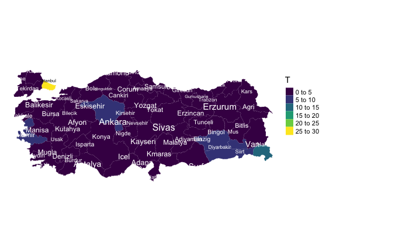

```r
tm_shape(dat_map) +
  tm_fill("T", palette = "viridis") +
  tm_layout(legend.outside = TRUE, frame = FALSE) +
  tm_text("province", size = "Shape_Area",  auto.placement = TRUE, legend.size.show = FALSE)
```

## 7.7 Set color intervals

Enter “style =” followed by one of the options below.

- equal: divides the range of the variable into n parts.
- pretty: chooses a number of breaks to fit a sequence of equality spaced ‘round’ values.
- quantile: equal number of cases in each group
- jenks: looks for natural breaks in the data
- cat: when the variable is categorical

```
The shape dat_map is invalid. See sf::st_is_valid
```

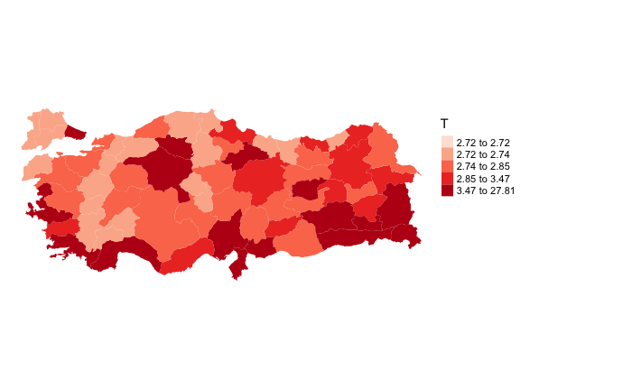

```r
tm_shape(dat_map) +
  tm_fill("T",
          style = "quantile",
          palette = "Reds"
    ) +
  tm_layout(
    legend.outside = TRUE,
    frame = FALSE)
```

Change the number of intervals in the color scheme and how the intervals are spaced. Changing the number of intervals n = 7. So, we have 7 shades instead of the default 5.

```
The shape dat_map is invalid. See sf::st_is_valid
```

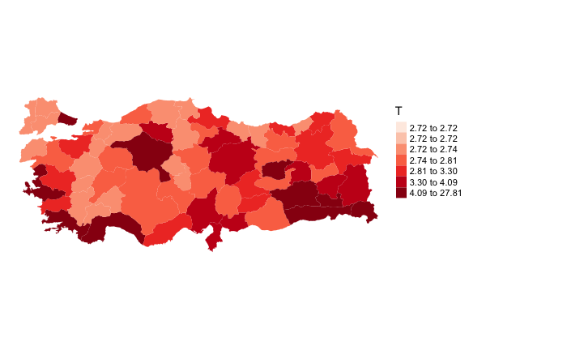

```r
tm_shape(dat_map) +
  tm_fill("T",
          style = "quantile",
          n = 7,
          palette = "Reds"
    ) +
  tm_layout(
    legend.outside = TRUE,
    frame = FALSE)
```

## 7.8 Add histogram

```
The shape dat_map is invalid. See sf::st_is_valid
```

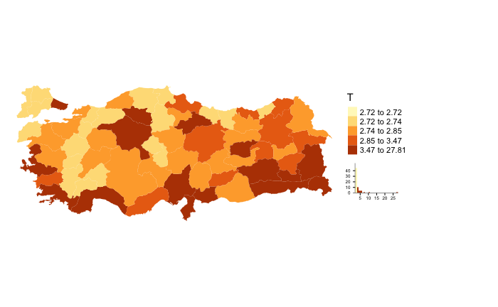

```r
tm_shape(dat_map) +
  tm_fill("T",
          style = "quantile",
          n = 5,
          palette = "YlOrBr",
          legend.hist = TRUE
    ) +
  tm_layout(
    legend.outside = TRUE,
    frame = FALSE)
```

## 7.9 Add borders

You can edit the borders of the shapefile with the tm_borders() function which has many arguments. alpha denotes the level of transparency on a scale from 0 to 1 where 0 is completely transparent.

```
The shape dat_map is invalid. See sf::st_is_valid
```

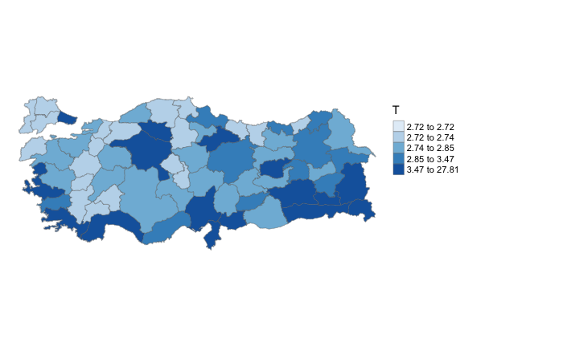

```r
tm_shape(dat_map) +
  tm_fill("T",
          style = "quantile",
          palette = "Blues"
    ) +
  tm_borders(alpha=.4) +
  tm_layout(
    legend.outside = TRUE,
    frame = FALSE)
```

## 7.10 Add compass

```
The shape dat_map is invalid. See sf::st_is_valid
```

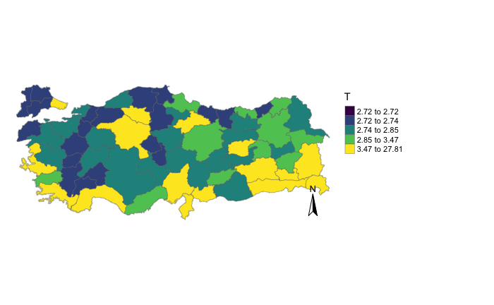

```r
tm_shape(dat_map) +
  tm_fill("T",
          style = "quantile",
          palette = "viridis"
    ) +
  tm_borders(alpha=.4) +
  tm_compass() +
  tm_layout(
    legend.outside = TRUE,
    frame = FALSE)
```

## 7.11 Edit the layout

```
The shape dat_map is invalid. See sf::st_is_valid
```

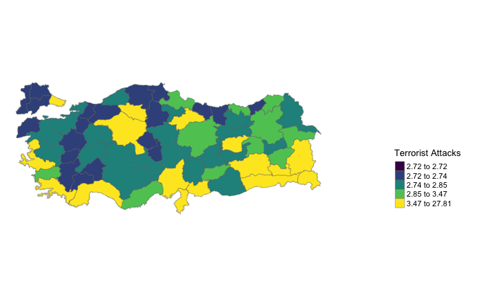

```r
tm_shape(dat_map) +
  tm_fill("T",
          palette = "viridis",
          style = "quantile",
          title = "Terrorist Attacks"
          ) +
tm_borders(alpha=.4) +
tm_layout(
  legend.text.size = 0.7,
  legend.title.size = 1,
  legend.position = c("right", "bottom"),
  legend.outside = TRUE,
  frame = FALSE
  )
```

## 7.12 Interactive map

```r
tmap_mode("view")
```

```
tmap mode set to interactive viewing
```

```r
tm_shape(dat_map) +
  tm_fill("T", palette = "viridis") +
  tm_layout(legend.outside = TRUE, frame = FALSE)
```

```
The shape dat_map is invalid. See sf::st_is_valid
```

[interactive chart not shown]

```r
tmap_mode("plot")
```

```
tmap mode set to plotting
```

# 8 Save a new shapefile

```r
st_write(dat_map, "dat_map.shp")
```

# 9 References

- [Practical 5: Making maps in R](https://data.cdrc.ac.uk/tutorial/aa5491c9-cbac-4026-97c9-f9168462f4ac/70c4bc61-0475-4806-9240-4ef1fa649a06)
- [Modern Geospatial Data Analysis with R](http://files.zevross.com/workshops/spatial/slides/html/0-deck-list.html)

# 10 Datasets

- [Non-spatial](https://github.com/quarcs-lab/tutorial-maps-in-r/blob/master/DATASET.zip?raw=true)
- [Spatial](https://github.com/quarcs-lab/tutorial-maps-in-r/blob/master/MAP.zip?raw=true)
- [Combined](https://github.com/quarcs-lab/tutorial-maps-in-r/blob/master/turkey_admin1_merge3_all.zip?raw=true)

END